# Bayesian Zero-inflated negative binomial Regression

2024-10-02

```r
library(tidyverse)        # ggplot, dplyr, %>%, and friends
library(brms)             # Bayesian modeling through Stan
library(marginaleffects)  # Calculate marginal effects for regression models
library(tidybayes)        # Manipulate Stan objects in a tidy way
library(patchwork)        # Combine ggplot objects
library(ggrepel)          # Automatically position labels
library(scales)           # Format numbers in nice ways
library(collapse)
library(broom)            # Convert model objects to data frames
library(broom.mixed)      # Convert brms model objects to data frames
library(extraDistr)       # Use extra distributions like dprop()
library(ggdist)           # Special geoms for posterior distributions
library(gghalves)         # Special half geoms
library(ggbeeswarm)       # Special distribution-shaped point jittering
library(modelsummary)     # Create side-by-side regression tables
library(ggthemes)
library(wesanderson)
library(gridExtra)        # Merge Graphs
```

### Country-level

Country-level relationship between proportion of sample and socioeconomic/cultural factors for traditional studies (using PS2014 as an example) and big team science (using PSA 001 as an example)

### Taking GDP per capita as an example

# 1 View data

```r
gdpdata <- read_csv("gdpdata.csv")%>%
  mutate(GDP_per_capita1 = log(GDP_per_capita))#Log Transformations
gdpdata
```

```
## # A tibble: 185 × 11
##    country country_map continent     GDP_per_capita   bts total_bts
##    <chr>   <chr>       <chr>                  <dbl> <dbl>     <dbl>
##  1 AND     AD          Europe                 42.0      0     11484
##  2 ARE     AE          Asia                   53.8     80     11484
##  3 ATG     AG          North America          18.7      0     11484
##  4 ARM     AM          Asia                    7.01     0     11484
##  5 AGO     AO          Africa                  3.00     0     11484
##  6 ARG     AR          South America          13.7     91     11484
##  7 AUT     AT          Europe                 52.1    236     11484
##  8 AUS     AU          Oceania                64.5    885     11484
##  9 AZE     AZ          Asia                    7.74     0     11484
## 10 BIH     BA          Europe                  7.59     0     11484
## # ℹ 175 more rows
## # ℹ 5 more variables: percentage_sample <dbl>, ps <dbl>, total_ps <dbl>,
## #   ps2014 <dbl>, GDP_per_capita1 <dbl>
```

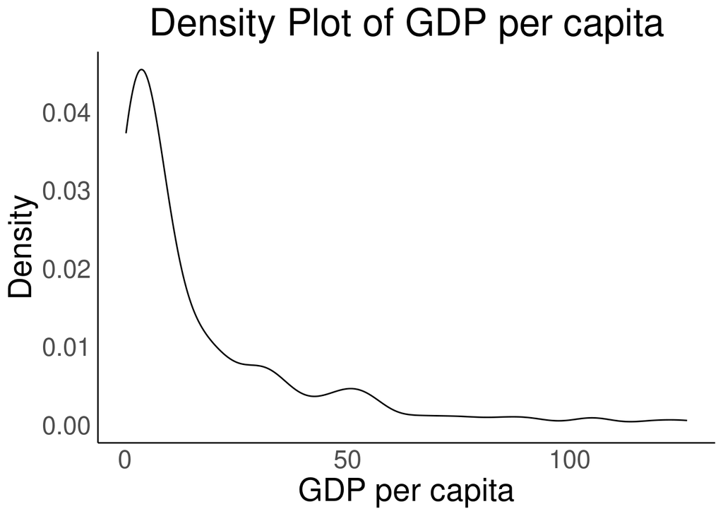

```r
#Observe the distribution of independent variables
ggplot(gdpdata, aes(x = GDP_per_capita)) +
  geom_density() +
  labs(title = "Density Plot of GDP per capita", x = "GDP per capita", y = "Density") +
    theme_bw() +
  theme_minimal()+
  theme(
    text = element_text(size = 22),
    plot.title = element_text(hjust = .5),
    panel.grid.major = element_blank(),
    panel.grid.minor = element_blank(),
    panel.border = element_blank(),
    strip.background =element_blank(),
    axis.line.x.bottom = element_line(color = 'black'),
    axis.line.y.left   = element_line(color = 'black'),
    legend.position = "none")
```

```r
#Normality test
shapiro.test(gdpdata$GDP_per_capita)
```

```
##
##  Shapiro-Wilk normality test
##
## data:  gdpdata$GDP_per_capita
## W = 0.7041, p-value < 2.2e-16
```

By examining the distribution map and the normality test, it can be seen that the distribution of the independent variables is not normal.Therefore, Therefore, we performed logarithmic transformation on the data of GDP per capita.

The data distribution of GDP per capita after logarithmic transformation is as follows

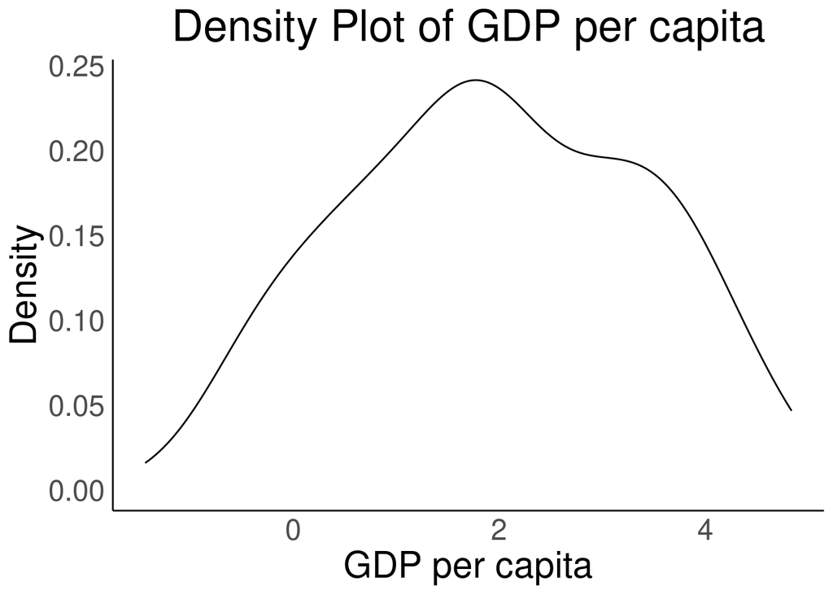

```r
#Observe the distribution of independent variables
ggplot(gdpdata, aes(x = GDP_per_capita1)) +
  geom_density() +
  labs(title = "Density Plot of GDP per capita", x = "GDP per capita", y = "Density") +
    theme_bw() +
  theme_minimal()+
  theme(
    text = element_text(size = 22),
    plot.title = element_text(hjust = .5),
    panel.grid.major = element_blank(),
    panel.grid.minor = element_blank(),
    panel.border = element_blank(),
    strip.background =element_blank(),
    axis.line.x.bottom = element_line(color = 'black'),
    axis.line.y.left   = element_line(color = 'black'),
    legend.position = "none")
```

```r
shapiro.test(gdpdata$GDP_per_capita1)
```

```
##
##  Shapiro-Wilk normality test
##
## data:  gdpdata$GDP_per_capita1
## W = 0.98238, p-value = 0.01969
```

The sample size of our dependent variable is count data and contains many zeros. However, it is still unknown whether the data is over-dispersion. Below we will use QQ-plots to examine the dispersion of non-zero data.

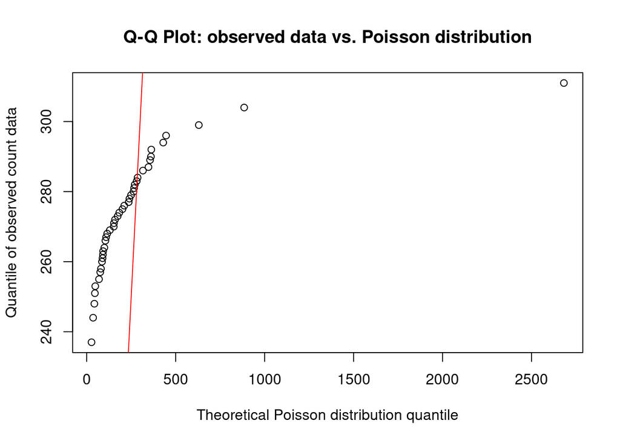

```r
bts0 <- gdpdata[gdpdata$bts != 0, ]$bts

lambda <- mean(bts0)
theoretical_quantiles <- qpois(ppoints(length(bts0)), lambda)


qqplot(bts0, theoretical_quantiles,
       xlab = "Theoretical Poisson distribution quantile",
       ylab = "Quantile of observed count data",
       main = "Q-Q Plot: observed data vs. Poisson distribution")
abline(0, 1, col = "red")
```

In the QQ-plots above, the circle does not coincide with the red line, indicating a significant difference between the observed data and the theoretical data of the Poisson distribution, which represents over-dispersion.